# Client Report - Can You Predict That?

- Show All Code
- Hide All Code

Course DS 250

Author

Saylor Tippetts

```python
import pandas as pd
import numpy as np
from lets_plot import *
from sklearn.ensemble import GradientBoostingClassifier
from sklearn.model_selection import train_test_split
from sklearn.ensemble import RandomForestClassifier
from sklearn.metrics import accuracy_score, classification_report

# add the additional libraries you need to import for ML here

LetsPlot.setup_html(isolated_frame=True)
```

```python
# Learn morea about Code Cells: https://quarto.org/docs/reference/cells/cells-jupyter.html
import pandas as pd

url = "https://raw.githubusercontent.com/byuidatascience/data4dwellings/master/data-raw/dwellings_ml/dwellings_ml.csv"
df = pd.read_csv(url)
```

## QUESTION|TASK 1

**Create 2-3 charts that evaluate potential relationships between the home variables and `before1980`.** Explain what you learn from the charts that could help a machine learning algorithm.

*These charts simply give more insight into the data that we are looking at.*

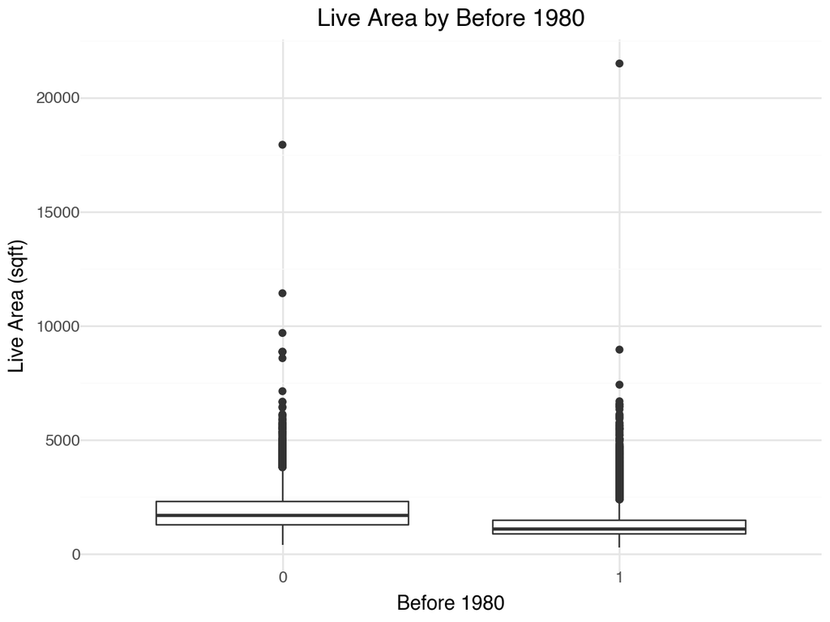

```python
from plotnine import *

(ggplot(df, aes(x='factor(before1980)', y='livearea')) +
    geom_boxplot() +
    labs(title="Live Area by Before 1980", x="Before 1980", y="Live Area (sqft)") +
    theme_minimal())
```

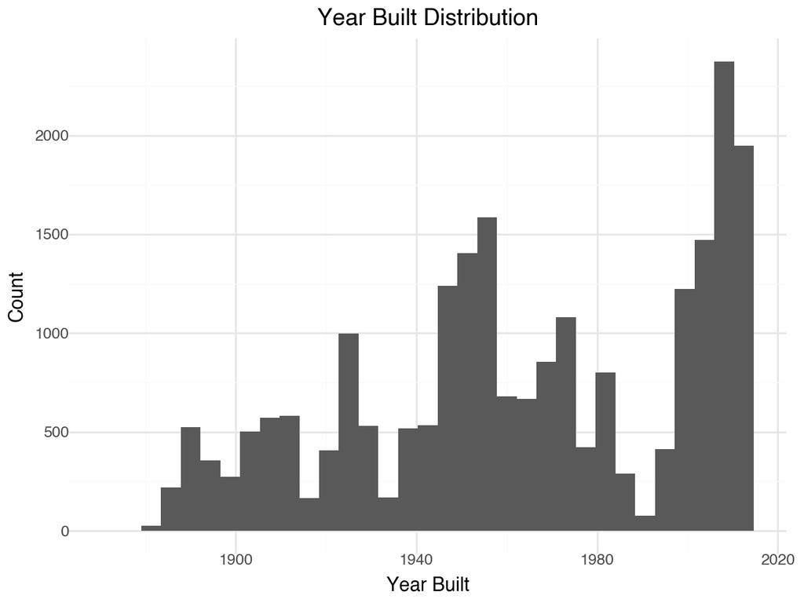

```python
( ggplot(df, aes(x='yrbuilt')) +
    geom_histogram() +
    labs(title="Year Built Distribution", x="Year Built", y="Count") +
    theme_minimal())
```

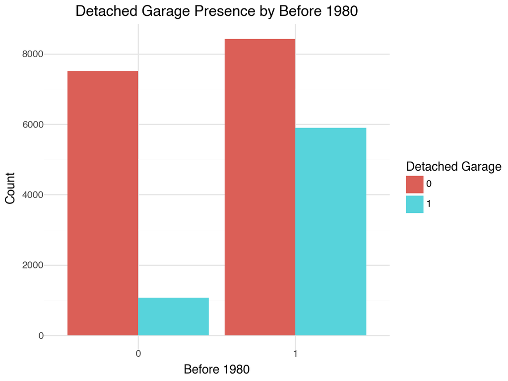

```python
( ggplot(df, aes(x='factor(before1980)', fill='factor(gartype_Det)')) +
    geom_bar(position='dodge') +
    labs(title="Detached Garage Presence by Before 1980", x="Before 1980", y="Count", fill="Detached Garage") +
    theme_minimal())
```

## QUESTION|TASK 2

**Build a classification model labeling houses as being built “before 1980” or “during or after 1980”.** Your goal is to reach or exceed 90% accuracy. Explain your final model choice (algorithm, tuning parameters, etc) and describe what other models you tried.

*I used the Random Forest Classifier and set my estimator to 200. I ended up getting 90% accuracy.*

```python
df = df.drop(columns=['parcel', 'yrbuilt'])

X = df.drop(columns=['before1980'])
y = df['before1980']

X_train, X_test, y_train, y_test = train_test_split(X, y, stratify=y, random_state=42)

rf = RandomForestClassifier(n_estimators=200, max_depth=10, random_state=42)
rf.fit(X_train, y_train)

y_pred = rf.predict(X_test)

print(" Accuracy:", accuracy_score(y_test, y_pred))
print("\nClassification Report:\n", classification_report(y_test, y_pred))
```

```
 Accuracy: 0.8996334438820038

Classification Report:
               precision    recall  f1-score   support

           0       0.88      0.85      0.86      2149
           1       0.91      0.93      0.92      3580

    accuracy                           0.90      5729
   macro avg       0.89      0.89      0.89      5729
weighted avg       0.90      0.90      0.90      5729
```

## QUESTION|TASK 3

**Justify your classification model by discussing the most important features selected by your model.** This discussion should include a feature importance chart and a description of the features.

*For this, I did a simple Bar Chart ro showase the 10 most important features.*

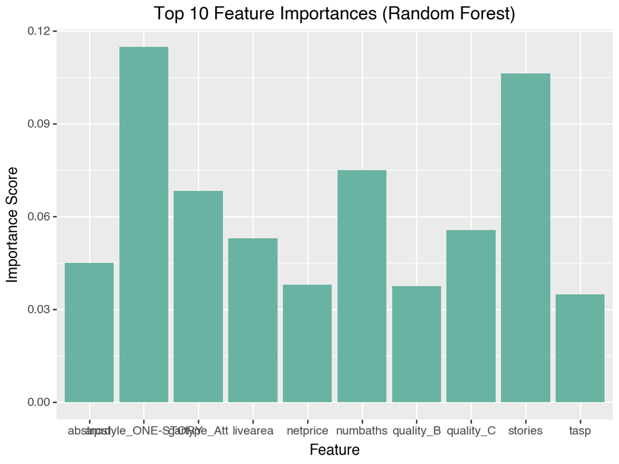

```python
importances = pd.Series(rf.feature_importances_, index=X.columns)

# 2. Convert to DataFrame and keep top 10
importance_df = importances.nlargest(10).reset_index()
importance_df.columns = ['feature', 'importance']


(
    ggplot(importance_df, aes(x='feature', y='importance')) +
    geom_col(fill="#69b3a2") +
    labs(title='Top 10 Feature Importances (Random Forest)',
         x='Feature',
         y='Importance Score'))
```

## QUESTION|TASK 4

**Describe the quality of your classification model using 2-3 different evaluation metrics.** You also need to explain how to interpret each of the evaluation metrics you use.

*For this, I decided to important the accuracy score and classification report. These just tell more details about small things within the test.*

```python
# Include and execute your code here
from sklearn.metrics import accuracy_score
accuracy_score(y_test, y_pred)

from sklearn.metrics import classification_report
print(classification_report(y_test, y_pred))
```

```
              precision    recall  f1-score   support

           0       0.88      0.85      0.86      2149
           1       0.91      0.93      0.92      3580

    accuracy                           0.90      5729
   macro avg       0.89      0.89      0.89      5729
weighted avg       0.90      0.90      0.90      5729
```

## STRETCH QUESTION|TASK 1

**Repeat the classification model using 3 different algorithms.** Display their Feature Importance, and Decision Matrix. Explian the differences between the models and which one you would recommend to the Client.

```python
# Include and execute your code here
```

[output not shown]

## STRETCH QUESTION|TASK 2

**Join the `dwellings_neighborhoods_ml.csv` data to the `dwelling_ml.csv` on the `parcel` column to create a new dataset. Duplicate the code for the stretch question above and update it to use this data.** Explain the differences and if this changes the model you recomend to the Client.

```python
# Include and execute your code here
```

[output not shown]

## STRETCH QUESTION|TASK 3

**Can you build a model that predicts the year a house was built?** Explain the model and the evaluation metrics you would use to determine if the model is good.

```python
# Include and execute your code here
```

[output not shown]